# Google Data Analytics Capstone Project Report - Cyclistic Case Study

```r
#Summarize users by type and day of week
Cyclistic_trips_2019_formatted %>%
  group_by(usertype, day_of_week) %>%
  summarise(total_rides = n(), avg_ride = mean(ride_duration)) %>%
  arrange(day_of_week)
```

```
## # A tibble: 14 x 4
## # Groups:   usertype [2]
##    usertype   day_of_week total_rides avg_ride
##    <chr>      <ord>             <int> <drtn>
##  1 Casual     Monday           101355 39.28936 mins
##  2 Subscriber Monday           458714 12.64233 mins
##  3 Casual     Tuesday           88495 37.57701 mins
##  4 Subscriber Tuesday          496951 12.58757 mins
##  5 Casual     Wednesday         89601 36.68408 mins
##  6 Subscriber Wednesday        494205 12.62722 mins
##  7 Casual     Thursday         101203 37.39291 mins
##  8 Subscriber Thursday         486837 12.64583 mins
##  9 Casual     Friday           120934 38.31765 mins
## 10 Subscriber Friday           456890 12.54320 mins
## 11 Casual     Saturday         207760 41.54985 mins
## 12 Subscriber Saturday         287078 14.46396 mins
## 13 Casual     Sunday           169935 41.33581 mins
## 14 Subscriber Sunday           256184 14.22741 mins
```

**Visualizations**

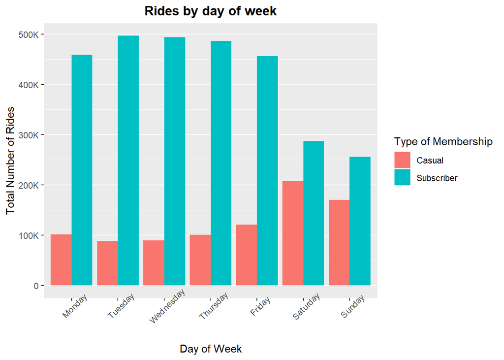

```r
#Summary of total rides by day of week
Cyclistic_trips_2019_formatted %>%
  group_by(usertype, day_of_week) %>%
  summarise(no_of_rides = n() ) %>%
  arrange(usertype, day_of_week) %>%
  ggplot(aes(x = day_of_week, y = no_of_rides, fill = usertype)) +
  geom_col(position = "dodge") +
  labs(x= 'Day of Week', y='Total Number of Rides', title='Rides by day of week', fill = 'Type of Membership') +
  scale_y_continuous(breaks = c(0,100000, 200000, 300000, 400000, 500000), labels = c("0", "100K", "200K", "300K", "400K", "500K"))+
  theme(axis.text.x = element_text(angle = 45), panel.grid.major.x = element_blank(),panel.grid.minor.x = element_blank(), plot.title = element_text(face = "bold", hjust = 0.5))
```

Inference : Subscriber-rides peak during the week (Monday to Friday). Ride utilization for subscribers is higher when compared to casual riders. Therefore, it can be concluded that rides are primarily utilized for commute to workplaces.

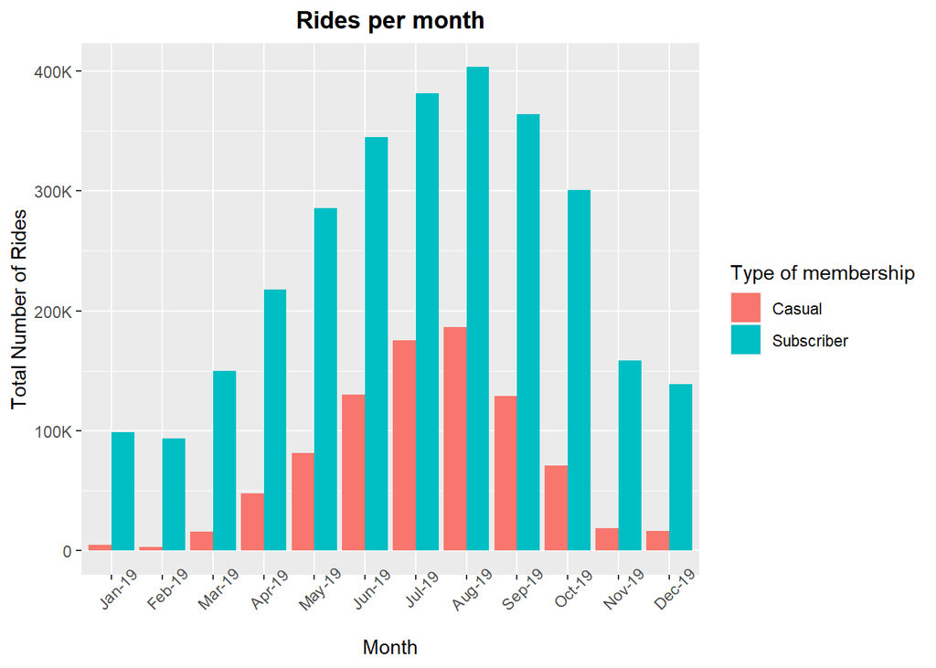

```r
#Summary of total rides broken down by month
Cyclistic_trips_2019_formatted %>%
  group_by(usertype, month) %>%
  summarise(total_no_of_rides = n()) %>%
  arrange(usertype, month) %>%
  ggplot(aes(x = month, y=total_no_of_rides, fill = usertype)) +
  geom_col(position = "dodge") +
  labs(x= "Month", y= "Total Number of Rides", title = "Rides per month", fill = "Type of membership") +
  scale_y_continuous(breaks = c(0,100000, 200000, 300000, 400000, 500000), labels = c("0", "100K", "200K", "300K", "400K", "500K")) +
  theme(axis.text.x = element_text(angle = 45),plot.title = element_text(face = "bold", hjust = 0.5))
```

Inference: The average number of rides per month for subscribers is longer than casual riders. Both subscribers and casual riders have a similar usage pattern across months.

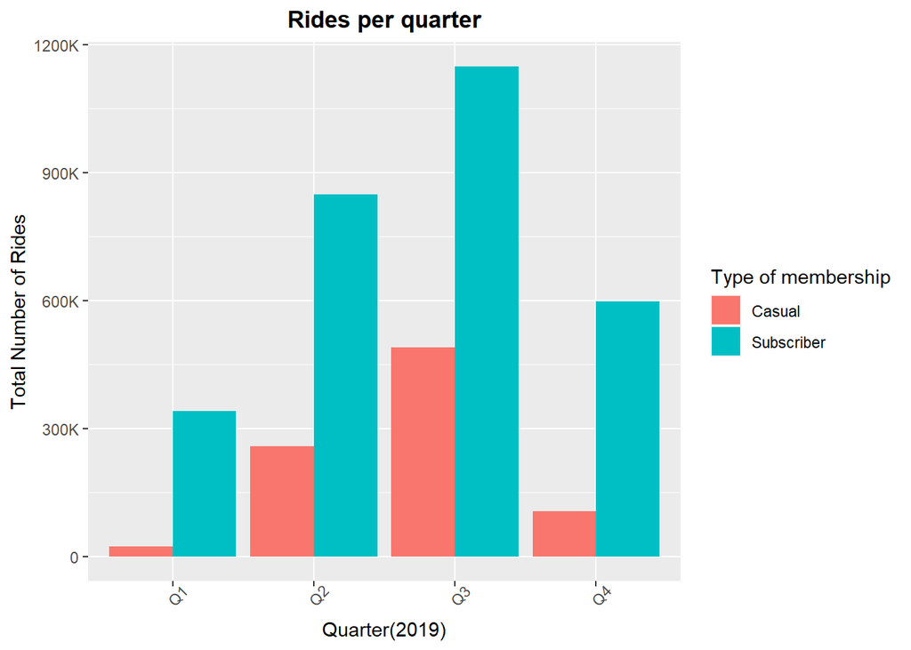

```r
#Summary of total rides broken down by quarter
Cyclistic_trips_2019_formatted %>%    #total rides broken down by quarter
  group_by(usertype, quarters) %>%
  summarise(total_no_of_rides = n()) %>%
  arrange(usertype, quarters) %>%
  ggplot(aes(x = quarters, y=total_no_of_rides, fill = usertype)) +
  geom_col(position = "dodge") +
  labs(x= "Quarter(2019)", y= "Total Number of Rides", title = "Rides per quarter", fill = "Type of membership") +
  scale_y_continuous(breaks = c(0,300000, 600000, 900000, 1200000, 1500000), labels = c("0", "300K", "600K", "900K", "1200K", "1500K")) +
  theme(axis.text.x = element_text(angle = 45),plot.title = element_text(face = "bold", hjust = 0.5))
```

Inference: For both subscribers and casual riders, the first and last quarters of the year show lower utilization of rides, while the utilization levels are higher for the remaining two quarters. This implies that utilization levels are lower during the winter months when compared to the summer.

```
## Defaulting to continuous.
```

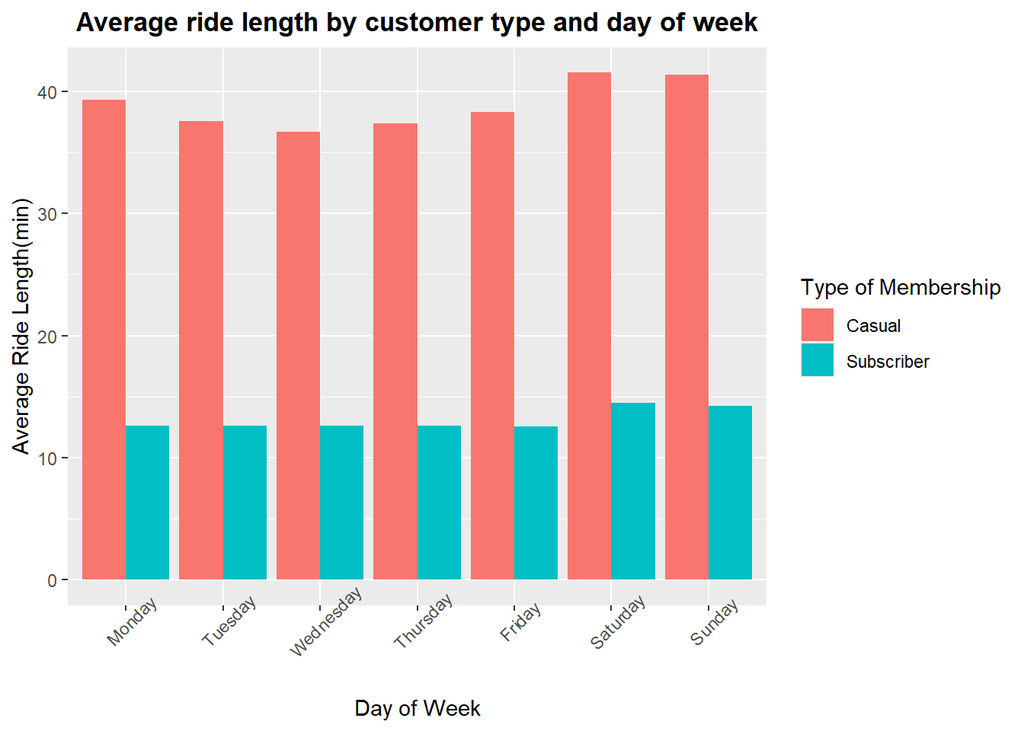

```r
#Summary of Average ride length by Customer type and Day of week
Cyclistic_trips_2019_formatted %>%
  group_by(usertype, day_of_week) %>%
  summarise(average_ride_length = mean(ride_duration)) %>%
  ggplot(aes(x=day_of_week, y = average_ride_length, fill = usertype))+
  geom_col(position = "dodge") + labs (x="Day of Week", y="Average Ride Length(min)",
             title = "Average ride length by customer type and day of week",
             fill = "Type of Membership") +
  theme(axis.text.x = element_text(angle = 45), plot.title = element_text(face = "bold", hjust = 0.5))
```

Inference: The average ride length per day for casual riders is higher than subscribers.

```
## Defaulting to continuous.
```

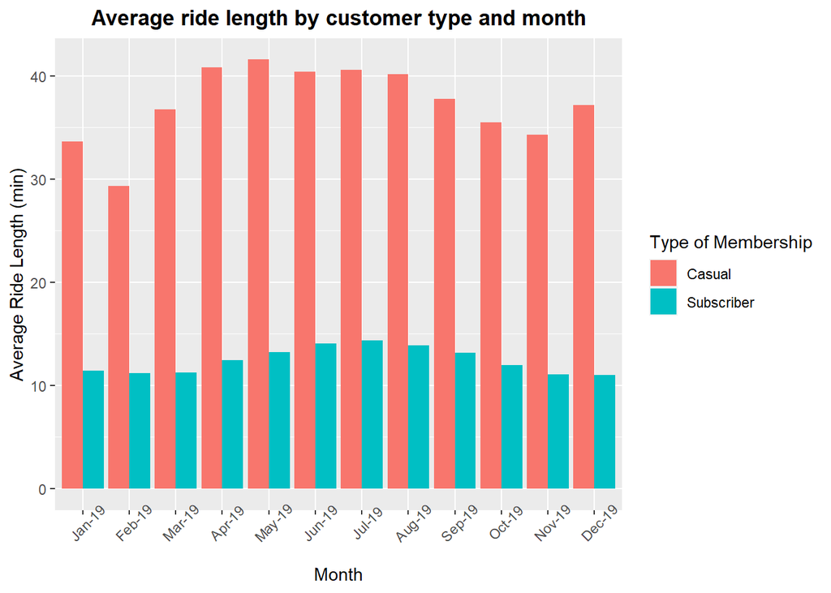

```r
#Average ride length by customer type and month
Cyclistic_trips_2019_formatted %>%
  group_by(usertype, month) %>%
  summarise(average_ride_length = mean(ride_duration)) %>%
  ggplot(aes(x=month, y = average_ride_length, fill = usertype))+
  geom_col(position = "dodge") +
  labs (x="Month", y = "Average Ride Length (min)", title = "Average ride length by customer type and month",
        fill = "Type of Membership") + theme(axis.text.x = element_text(angle = 45), plot.title = element_text(face = "bold", hjust = 0.5))
```

Inference: The average ride length per month for casual riders is relatively longer than subscribers.

**Conclusions:**

**Recommendations:**

- Campaigns on promotions for annual memberships during the lean months to boost sales and to convert casual riders into annual subscribers.
- Decrease in the price of one-way tickets and two-way tickets during work-days to encourage increase in casual riders during the week.
- Increase in the price of one-way tickets and two-way tickets on weekends, so that casual riders switch to subscriptions.
- Increase in bike-availability at starting-stations that have higher subscriber bookings on week days.

**Addendum:**

Additional input data that would be useful for further analysis:

- Age and gender : to identify demographics of existing customers for planning promotional offers.
- Block bookings : to identify strategies to target entire families or groups of riders based on their usage patterns.
- Pricing plans : for cost benefit analysis and to identify campaigns to target specific rider-types.
- Geographical data : for targeting potential customers from specific localities or districts based on rider patterns.
- Ride-type data : to plan strategic locations for positioning docking stations and availability of alternative bike-types to ensure maximum utilization and subscription.

**References:**

Google Data Analytics course modules